# Predicting and Ranking Stock Market Prices of the S&P500

### Spring 2024 Data Science Project

Brandon Lee, Andrew Liu, Ashley

Contribution Summary

Member 1: Brandon Lee, Contribution: 100%.

Member 2: Andrew Liu, Contribution: 100%.

Member 3: Ashley, Contribution: 100%.

"We, all team members, agree together that the above information is true, and we are confident about our contributions to this submitted project/final tutorial."

List all of your full names with date

Brandon Lee - 5/7/2024

Andrew Liu - 5/7/2024

Ashley - 5/7/2024

Brandon Lee: Worked on the introduction, data exploration analysis, and primary analysis sections.

Andrew: Worked on data curation, data exploration analysis and conclusion

Ashley: Worked on data visualization, exploration analysis and conclusion

## INTRODUCTION

The Standard & Poor's 500 Index (S&P500) is a market capitalization weighted index of the 500 highest publically traded companies in the US. Because of the number and diversity of stocks in the index, it is considered a suitable metric for how the general stock market is performing (https://www.investopedia.com/terms/s/sp500.asp). Because each stock is screened and is required to have certain prerequisite, investors often look at these stocks to invest in as they are generally fundamentally sound, however as we will discover in this project, underperforming stocks are not uncommon. The goal of every investor is the same which is the maximize profits or return on their investments (ROI) which is all about identifying when to enter and exit a stock. In this project our emphasis will be to focus on finding the best time to enter a stock.

The objective of this project will be to analyze the previous stock market prices of the S&P500 every trading day from 2013 to 2018 in order to help predict the prices of each stock in the future. In this review, using machine learning methods, we will attempt to build a model that is capable of accurately predicting future stock prices given a specific time with the ultimate goal of being able to advise an investor if the stock has a good expected ROI. In this project we will also use a linear regression model to determine the top 5 best and worst performing stocks in the S&P500. This information could be useful and significant in making smart investments in the stock market and can be applied to future investments.

Our project is divided up into six sections:

- Introduction
- Data Curation
- Exploratory Data Analysis
- Primary Analysis
- Visualization
- Insights and Conclusion

We will first start by importing the neccesary modules:

```python
import pandas as pd
import matplotlib.pyplot as plt
import torch
import torch.nn as nn
import torch.optim as optim
import numpy as np
import warnings

from scipy import stats
from torch.utils.data import DataLoader, TensorDataset
from sklearn.model_selection import train_test_split
from sklearn.preprocessing import StandardScaler
from sklearn.linear_model import LinearRegression
from sklearn.metrics import mean_squared_error
from datetime import datetime
```

## DATA CURATION

We got our data from Kaggle, the dataset was provided in a csv file. In this dataset, it includes all stocks prices between Feburary of 2013 to Feburary of 2018. There are 7 features in this dataset. They are date representing date of stock, open representing the opening price (the price of stock when stock market opens during the day) of a stock on a given date. Close representing the closing price of a stock on a given date. High representing the highest price that stock has reached during a given date. Low representing the lowest point that stock reached during a given date. Volume representing number of trades occurred on a given stock throughout the day. Finally Name representing the name abbreviation of a stock.

In this section, we will clean the data set that was provided to us, such as filling in missing datas and reformatting datas to be consistent amongst each other.

Download the data and store it in DataFrame using Pandas

```python
from google.colab import drive
#had to change filename/link my google drive so i could run this locally
df = pd.read_csv('all_stocks_5yr.csv')
#df = pd.read_csv('/content/gdrive/MyDrive/all_stocks_5yr.csv')
df
```

|  | date | open | high | low | close | volume | Name |
| --- | --- | --- | --- | --- | --- | --- | --- |
| 0 | 2013-02-08 | 15.07 | 15.12 | 14.63 | 14.75 | 8407500 | AAL |
| 1 | 2013-02-11 | 14.89 | 15.01 | 14.26 | 14.46 | 8882000 | AAL |
| 2 | 2013-02-12 | 14.45 | 14.51 | 14.10 | 14.27 | 8126000 | AAL |
| 3 | 2013-02-13 | 14.30 | 14.94 | 14.25 | 14.66 | 10259500 | AAL |
| 4 | 2013-02-14 | 14.94 | 14.96 | 13.16 | 13.99 | 31879900 | AAL |
| ... | ... | ... | ... | ... | ... | ... | ... |
| 619035 | 2018-02-01 | 76.84 | 78.27 | 76.69 | 77.82 | 2982259 | ZTS |
| 619036 | 2018-02-02 | 77.53 | 78.12 | 76.73 | 76.78 | 2595187 | ZTS |
| 619037 | 2018-02-05 | 76.64 | 76.92 | 73.18 | 73.83 | 2962031 | ZTS |
| 619038 | 2018-02-06 | 72.74 | 74.56 | 72.13 | 73.27 | 4924323 | ZTS |
| 619039 | 2018-02-07 | 72.70 | 75.00 | 72.69 | 73.86 | 4534912 | ZTS |

619040 rows × 7 columns

Convert date using pandas.to_datetime

```python
df['date'] = pd.to_datetime(df['date'])
display(df)
```

|  | date | open | high | low | close | volume | Name |
| --- | --- | --- | --- | --- | --- | --- | --- |
| 0 | 2013-02-08 | 15.07 | 15.12 | 14.63 | 14.75 | 8407500 | AAL |
| 1 | 2013-02-11 | 14.89 | 15.01 | 14.26 | 14.46 | 8882000 | AAL |
| 2 | 2013-02-12 | 14.45 | 14.51 | 14.10 | 14.27 | 8126000 | AAL |
| 3 | 2013-02-13 | 14.30 | 14.94 | 14.25 | 14.66 | 10259500 | AAL |
| 4 | 2013-02-14 | 14.94 | 14.96 | 13.16 | 13.99 | 31879900 | AAL |
| ... | ... | ... | ... | ... | ... | ... | ... |
| 619035 | 2018-02-01 | 76.84 | 78.27 | 76.69 | 77.82 | 2982259 | ZTS |
| 619036 | 2018-02-02 | 77.53 | 78.12 | 76.73 | 76.78 | 2595187 | ZTS |
| 619037 | 2018-02-05 | 76.64 | 76.92 | 73.18 | 73.83 | 2962031 | ZTS |
| 619038 | 2018-02-06 | 72.74 | 74.56 | 72.13 | 73.27 | 4924323 | ZTS |
| 619039 | 2018-02-07 | 72.70 | 75.00 | 72.69 | 73.86 | 4534912 | ZTS |

619040 rows × 7 columns

We were provided an extremely clean set of data to begin with, so not much needed to be done in this section.

## EXPLORATORY DATA ANALYSIS

In this section we will explore and preprocess our dataset by using various statistical methods and visualizations to better understand our data. We will use pandas DataFrame in order to store our data as well as add columns to the data frame that might make it easier for analysis.

First lets see the contents of our dataset using pandas.info():

```python
display(df.info())
```

```
<class 'pandas.core.frame.DataFrame'>
RangeIndex: 619040 entries, 0 to 619039
Data columns (total 7 columns):
 #   Column  Non-Null Count   Dtype
---  ------  --------------   -----
 0   date    619040 non-null  datetime64[ns]
 1   open    619029 non-null  float64
 2   high    619032 non-null  float64
 3   low     619032 non-null  float64
 4   close   619040 non-null  float64
 5   volume  619040 non-null  int64
 6   Name    619040 non-null  object
dtypes: datetime64[ns](1), float64(4), int64(1), object(1)
memory usage: 33.1+ MB
```

```
None
```

Next lets add a profit column (profit = close price - open price):

```python
df['profit'] = df['close'] - df['open']
display(df)
```

|  | date | open | high | low | close | volume | Name | profit |
| --- | --- | --- | --- | --- | --- | --- | --- | --- |
| 0 | 2013-02-08 | 15.07 | 15.12 | 14.63 | 14.75 | 8407500 | AAL | -0.32 |
| 1 | 2013-02-11 | 14.89 | 15.01 | 14.26 | 14.46 | 8882000 | AAL | -0.43 |
| 2 | 2013-02-12 | 14.45 | 14.51 | 14.10 | 14.27 | 8126000 | AAL | -0.18 |
| 3 | 2013-02-13 | 14.30 | 14.94 | 14.25 | 14.66 | 10259500 | AAL | 0.36 |
| 4 | 2013-02-14 | 14.94 | 14.96 | 13.16 | 13.99 | 31879900 | AAL | -0.95 |
| ... | ... | ... | ... | ... | ... | ... | ... | ... |
| 619035 | 2018-02-01 | 76.84 | 78.27 | 76.69 | 77.82 | 2982259 | ZTS | 0.98 |
| 619036 | 2018-02-02 | 77.53 | 78.12 | 76.73 | 76.78 | 2595187 | ZTS | -0.75 |
| 619037 | 2018-02-05 | 76.64 | 76.92 | 73.18 | 73.83 | 2962031 | ZTS | -2.81 |
| 619038 | 2018-02-06 | 72.74 | 74.56 | 72.13 | 73.27 | 4924323 | ZTS | 0.53 |
| 619039 | 2018-02-07 | 72.70 | 75.00 | 72.69 | 73.86 | 4534912 | ZTS | 1.16 |

619040 rows × 8 columns

Add capital gain column (if the profit is positive):

```python
def capital_gain(profit):
  if profit > 0:
    return "Yes"
  else:
    return "No"

df['capital_gain'] = df['profit'].apply(capital_gain)
display(df)
```

|  | date | open | high | low | close | volume | Name | profit | capital_gain |
| --- | --- | --- | --- | --- | --- | --- | --- | --- | --- |
| 0 | 2013-02-08 | 15.07 | 15.12 | 14.63 | 14.75 | 8407500 | AAL | -0.32 | No |
| 1 | 2013-02-11 | 14.89 | 15.01 | 14.26 | 14.46 | 8882000 | AAL | -0.43 | No |
| 2 | 2013-02-12 | 14.45 | 14.51 | 14.10 | 14.27 | 8126000 | AAL | -0.18 | No |
| 3 | 2013-02-13 | 14.30 | 14.94 | 14.25 | 14.66 | 10259500 | AAL | 0.36 | Yes |
| 4 | 2013-02-14 | 14.94 | 14.96 | 13.16 | 13.99 | 31879900 | AAL | -0.95 | No |
| ... | ... | ... | ... | ... | ... | ... | ... | ... | ... |
| 619035 | 2018-02-01 | 76.84 | 78.27 | 76.69 | 77.82 | 2982259 | ZTS | 0.98 | Yes |
| 619036 | 2018-02-02 | 77.53 | 78.12 | 76.73 | 76.78 | 2595187 | ZTS | -0.75 | No |
| 619037 | 2018-02-05 | 76.64 | 76.92 | 73.18 | 73.83 | 2962031 | ZTS | -2.81 | No |
| 619038 | 2018-02-06 | 72.74 | 74.56 | 72.13 | 73.27 | 4924323 | ZTS | 0.53 | Yes |
| 619039 | 2018-02-07 | 72.70 | 75.00 | 72.69 | 73.86 | 4534912 | ZTS | 1.16 | Yes |

619040 rows × 9 columns

Classify the Volume as low, average, or high

Find mean and standard deviation of the volume:

- low = 1 standard deviation or more below the mean
- average = between 1 and -1 standard deviation of the mean
- high = 1 standard deviation or more above the mean

```python
volume_mean = df['volume'].mean()
volume_std = df['volume'].std()
print("Volume Mean:", volume_mean)
print("Volume Standard Deviation:", volume_std)
lb = abs(volume_mean - volume_std)
ub = abs(volume_mean + volume_std)

def classify_volume(volume):
  if volume < lb:
    return "low"
  elif volume > lb and volume < ub:
    return "average"
  elif volume > ub:
    return "high"

df['volume_classification'] = df['volume'].apply(classify_volume)
display(df)
```

```
Volume Mean: 4321823.395568945
Volume Standard Deviation: 8693609.511967573
```

|  | date | open | high | low | close | volume | Name | profit | capital_gain | volume_classification |
| --- | --- | --- | --- | --- | --- | --- | --- | --- | --- | --- |
| 0 | 2013-02-08 | 15.07 | 15.12 | 14.63 | 14.75 | 8407500 | AAL | -0.32 | No | average |
| 1 | 2013-02-11 | 14.89 | 15.01 | 14.26 | 14.46 | 8882000 | AAL | -0.43 | No | average |
| 2 | 2013-02-12 | 14.45 | 14.51 | 14.10 | 14.27 | 8126000 | AAL | -0.18 | No | average |
| 3 | 2013-02-13 | 14.30 | 14.94 | 14.25 | 14.66 | 10259500 | AAL | 0.36 | Yes | average |
| 4 | 2013-02-14 | 14.94 | 14.96 | 13.16 | 13.99 | 31879900 | AAL | -0.95 | No | high |
| ... | ... | ... | ... | ... | ... | ... | ... | ... | ... | ... |
| 619035 | 2018-02-01 | 76.84 | 78.27 | 76.69 | 77.82 | 2982259 | ZTS | 0.98 | Yes | low |
| 619036 | 2018-02-02 | 77.53 | 78.12 | 76.73 | 76.78 | 2595187 | ZTS | -0.75 | No | low |
| 619037 | 2018-02-05 | 76.64 | 76.92 | 73.18 | 73.83 | 2962031 | ZTS | -2.81 | No | low |
| 619038 | 2018-02-06 | 72.74 | 74.56 | 72.13 | 73.27 | 4924323 | ZTS | 0.53 | Yes | average |
| 619039 | 2018-02-07 | 72.70 | 75.00 | 72.69 | 73.86 | 4534912 | ZTS | 1.16 | Yes | average |

619040 rows × 10 columns

### **Summary statistics**

Statistical Test #1: Testing if the volume of a stock has a correlation with whether that stock had a capital gain that day using ANOVA.

HO: The volume (low, average, high) of a stock does not have an effect on the likelihood of a capital gain on that stock

HA: The volume (low, average, high) of a stock does have an effect on the likelihood of a capital gain on that stock

Set alpha = 0.05

```python
volume_mapping = {'low': 1, 'average': 2, 'high': 3}
capital_gain_mapping = {'Yes': 1, 'No': 0}
df['volume_classification'] = df['volume_classification'].replace(volume_mapping)
df['capital_gain'] = df['capital_gain'].replace(capital_gain_mapping)
# ANOVA
f_statistic, p_value = stats.f_oneway(df['volume_classification'], df['capital_gain'])
print("Test Statistic:", f_statistic)
print("P-value:", p_value)
```

```
Test Statistic: 664455.7495976209
P-value: 0.0
```

Plot of Volume vs if a stock ends with capital gain:

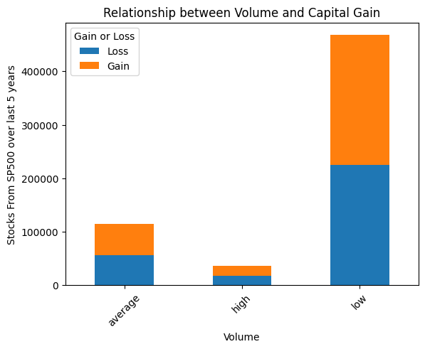

```python
volume_mapping = {1: 'low', 2: 'average', 3: 'high'}
df['volume_classification'] = df['volume_classification'].replace(volume_mapping)
table = pd.crosstab(index=df['volume_classification'], columns=df['capital_gain'])
plt.figure(figsize=(10, 6))
table.plot(kind='bar', stacked=True)
plt.title('Relationship between Volume and Capital Gain')
plt.xlabel('Volume')
plt.ylabel('Stocks From SP500 over last 5 years')
plt.xticks(rotation=45)
plt.legend(title='Gain or Loss', labels=['Loss', 'Gain'])
plt.show()
```

**Conclusion #1:**

Since the p_value (0) is less than alpha (0.05) we reject the null hypothesis and can conclude that the volume does in fact effect the likelihood of a stock ending the day with a capital gain

Statistical Testing #2: Testing if Year of a stock have any relation with capital gain on a stock by using Chi Squared Test.

HO: The Year of a stock does not have an effect on the likelihood of a capital gain on that stock

HA: The Year of a stock does have an effect on the likelihood of a capital gain on that stock

Set alpha = 0.05

Plot the frequency of Capital Gain or Loss by Year:

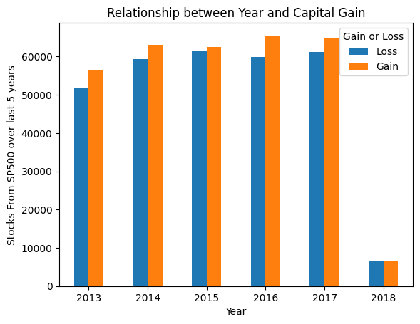

```python
def year_retreival(row):
  return row.year

df['year'] = df['date'].apply(year_retreival)
table2= pd.crosstab(df['year'], df['capital_gain'])
table2.plot(kind='bar')
plt.legend(title='Gain or Loss', labels=['Loss', 'Gain'])
plt.title("Relationship between Year and Capital Gain")
plt.xlabel('Year')
plt.ylabel('Stocks From SP500 over last 5 years')
plt.xticks(rotation=0)
plt.show()
```

Find P val:

```python
p_val_chi = stats.chi2_contingency(table2).pvalue
print(f'P-Value: {p_val_chi}')
```

```
P-Value: 1.96870502726467e-22
```

Conclusion #2

We found the P-Value for this test to be 1.96870502726467e-22 which is a extremely small positive decimal. Since the P-Value is smaller than the alpha value of 0.05. Then we reject the null hypothesis, and we say that "The Year of a stock does have an effect on the likelihood of a capital gain on that stock" is more likely to occur.

Statistical Testing #3:

Identifying outliers in the dataset, both in the combined dataset and split by volume and plotting these out. This will attempt to identify if certain trade volumes are more prone to outliers.

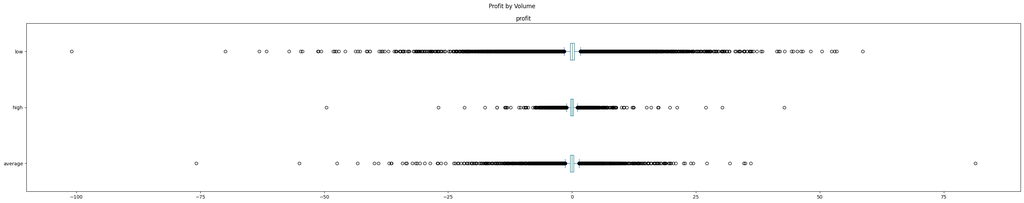

```python
boxplot = df.plot.box(column = ['profit'],by='volume_classification',figsize=(30,6),vert=False,title='Profit by Volume')
plt.tight_layout()
```

Immediately we realize that there are a significant number of outliers and a wide range of values, and due to the size of the dataset the boxplot is not a great visual aid. To better compare the distributions across the different trade volumes, we can adjust the Y scale to be logarithmic instead, and change our graph to instead be a histogram showing the frequency distribution of trades by profit

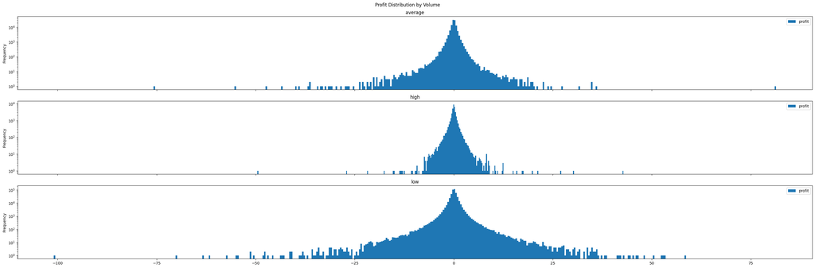

```python
histplot = df.plot.hist(column = ['profit'],by='volume_classification',figsize=(30,10),title='Profit Distribution by Volume',bins=400,logy=True,sharex=True)
plt.tight_layout()
```

## PRIMARY ANALYSIS

In this section we will look at how we can use linear regression to predict prices of stocks in the future. We will take a look at a few stocks in the S&P500 and use a linear regression model in order to find a reasonable prediction for its price given a specific date. We will take a look at some plots as well as error metrics in order to fully understand what our model is capable of and offer some ways we could potentially improve its accuracy. Finally we will use our analysis in order to determine the top 5 best and worst performing stocks in the S&P500

First lets create a linear regression model class with the following methods:

- plot(): this function plots the linear regression model with the actual data along with the linear regression line
- predict(date): this function takes in a date and predicts the close price of the stock on that date. It also calculates the residual sum squared to measure the residual error of the predicted value with the actual value
- get_slope(): returns the slope of the linear regression line
- showError(): plots the residual error of the linear regression line

```python
from sklearn.metrics import PredictionErrorDisplay
class LinearRegModel():
  def __init__(self, stock_name):
    self.stock_name = stock_name
    self.data = df[(df['Name'] == stock_name)].copy()
    # get features
    start_date = self.data['date'].min()
    self.data['Days'] = (self.data['date'] - start_date).dt.days

    # split dataset into training/testing
    self.X = self.data[['Days']]
    self.y = self.data['close']
    self.X_train, self.X_test, self.y_train, self.y_test = train_test_split(self.X, self.y, test_size=0.2, random_state=42)

    # train model using lin regression
    self.model = LinearRegression()
    self.model.fit(self.X_train, self.y_train)

  def plot(self):
    plt.figure(figsize=(10, 6))
    plt.scatter(self.data['date'], self.data['close'], color='blue', label='Actual Closing Prices')

    # plot the linear regression line
    plt.plot(self.data['date'], self.model.predict(self.X), color='red', label='Linear Regression Line')

    plt.xlabel('Date')
    plt.ylabel('Closing Price')
    plt.title(f'Closing Prices vs Linear Regression Line of {self.stock_name}')
    plt.legend()
    plt.grid(True)
    plt.show()

  # takes in date outputs predicted close price of stock
  def predict(self, date):
    date_to_predict = date
    date_to_predict = datetime.strptime(date_to_predict, '%Y-%m-%d')
    start_date = self.data['date'].min()
    days_since_start = (date_to_predict - start_date).days

    days_since_start = np.array([[days_since_start]])
    predicted_close_price = self.model.predict(days_since_start)
    actual_close_price = self.data[(self.data['date'] == date)]['close'].values[0]

    residuals = actual_close_price - predicted_close_price[0]
    # calculate residual sum squared error
    RSS = np.sum(residuals**2)
    print('Predicted Closing Price:', predicted_close_price[0])
    print('Actual Closing Price:', actual_close_price)
    print('Residual Error (RSS):', RSS)

  def get_slope(self):
    return self.model.coef_[0]

  def showError(self):
    y_pred = self.model.predict(self.X_test)
    display = PredictionErrorDisplay.from_estimator(self.model,self.X,self.y)
    plt.title(f"Actual vs Predicted Values for {self.stock_name}")
    #display.plot()
    plt.show()
```

Lets now use this model to take a look at a specific stock (AAPL):

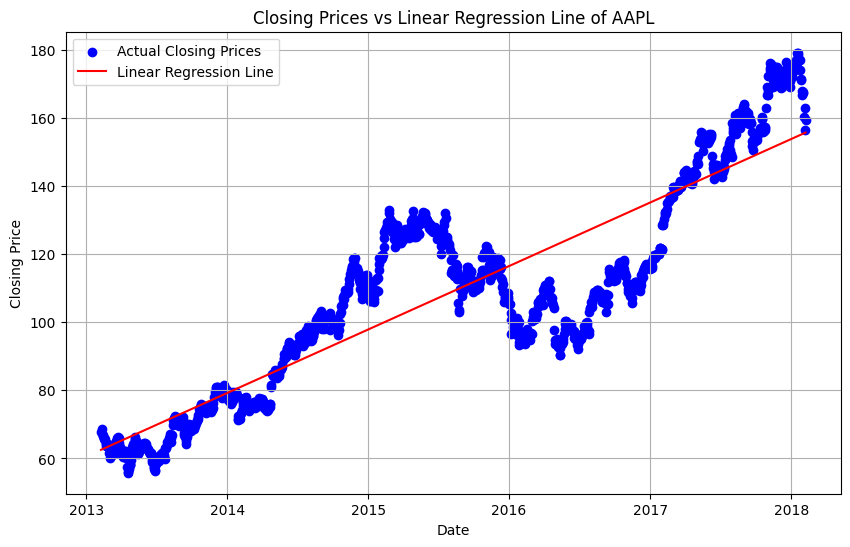

```python
model = LinearRegModel('AAPL')
model.plot()
```

As you can see above this plot represents the linear regression model of Apple's stock price from 2013 to 2018 where the blue dots represent the actual closing prices and the red line represents the predicted values or the linear regression line.

Now lets use this model to predict close prices given a date:

```python
warnings.filterwarnings("ignore", category=UserWarning)
model.predict('2015-10-12')
```

```
Predicted Closing Price: 112.40293719106504
Actual Closing Price: 111.6
Residual Error (RSS): 0.6447081327954184
```

We can see that our model did pretty good here where it was only off by about $0.80 or a residual sum squared error of 0.6447.

However our model has its limitations as we will see in the next example:

```python
warnings.filterwarnings("ignore", category=UserWarning)
model.predict('2016-5-12')
```

```
Predicted Closing Price: 123.28775156498624
Actual Closing Price: 90.34
Residual Error (RSS): 1085.5543331880529
```

As we can see there are some limitations to our model as it cannot fully fit to the data because our model is not complex enough. Because of this while some predictions have a small residual error, others can have pretty large errors too. To get around this limitation and improve our accuracy and consistency we could implement more complex ML models such as using polynomial regression, decision tree regression, or a KNN.

Now let find out and recommend which stocks are the best and worst in the S&P500 to invest in. In order to achieve this we will create a regression model for each stock and see which linear regression line has the highest and lowest slope in order to determine which is projected to grow the fastest or slowest. For this project we will recommend the top 5 and bottom 5 stocks according to our model.

```python
# format: {stock_name : slope_of_stock}
best_stocks = {'slot1': 0, 'slot2': 0, 'slot3': 0, 'slot4': 0, 'slot5': 0}
worst_stocks = {'slot1': 0, 'slot2': 0, 'slot3': 0, 'slot4': 0, 'slot5': 0}

for stock_name in df['Name'].unique():
  model = LinearRegModel(stock_name)
  slope = model.get_slope()

  if slope > min(best_stocks.values()):
    # replace with lowest slope in best_stocks
    for key, val in best_stocks.items():
      if val == min(best_stocks.values()):
          old_key = key

    del best_stocks[old_key]
    best_stocks[stock_name] = slope

  elif slope < max(worst_stocks.values()):
    # replace with the highest slope in worst_stocks
    for key, val in worst_stocks.items():
      if val == max(worst_stocks.values()):
          old_key = key

    del worst_stocks[old_key]
    worst_stocks[stock_name] = slope


# Sort
best_stocks = sorted(best_stocks.items(), key=lambda x: x[1], reverse=True)
best_stocks = dict(best_stocks)
worst_stocks = sorted(worst_stocks.items(), key=lambda x: x[1], reverse=False)
worst_stocks = dict(worst_stocks)
print("Top 5 Best Performing Stocks:\n", best_stocks)
print("Top 5 Worst Performing Stocks:\n", worst_stocks)
```

```
Top 5 Best Performing Stocks:
 {'PCLN': 0.5519115672063424, 'AMZN': 0.5014437208529379, 'GOOG': 0.37980049998602033, 'GOOGL': 0.33870956333651886, 'MTD': 0.22953014822701537}
Top 5 Worst Performing Stocks:
 {'EVHC': -0.09948035709429208, 'CMG': -0.07826853581747316, 'RL': -0.06301643793855223, 'UA': -0.04574875204228674, 'RRC': -0.041498618590579094}
```

Lets take a look at some of the plots of the best and worst stocks that our model classified.

Here what the best stocks looks like:

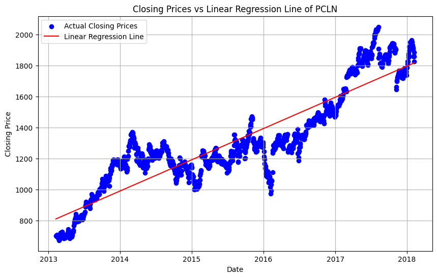

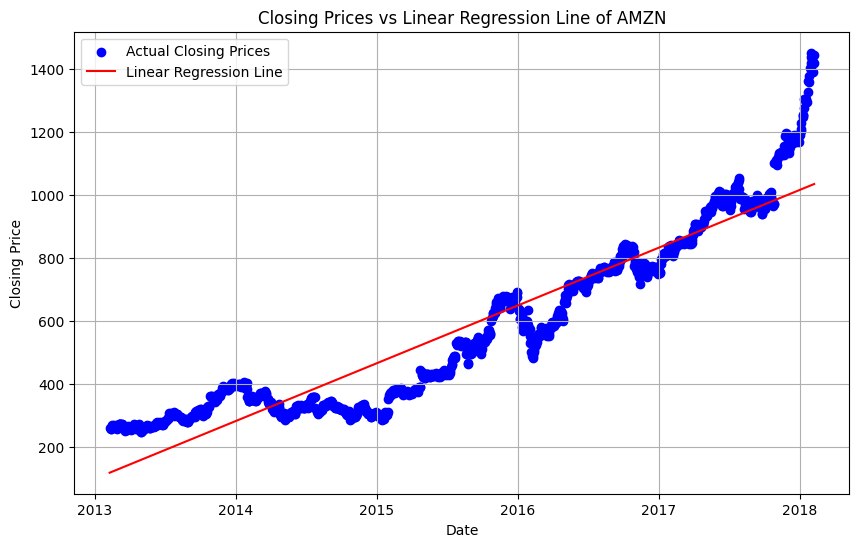

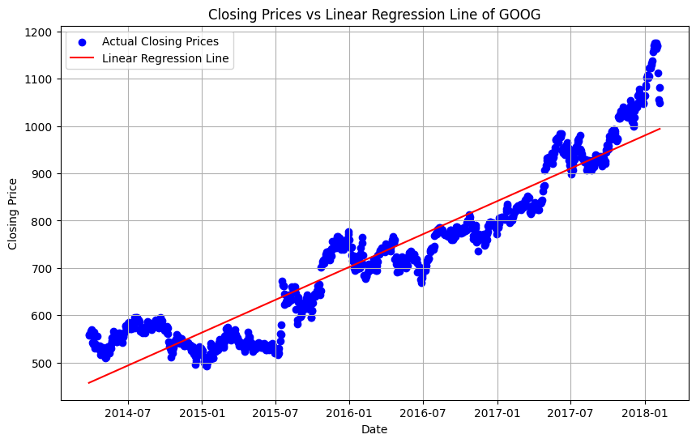

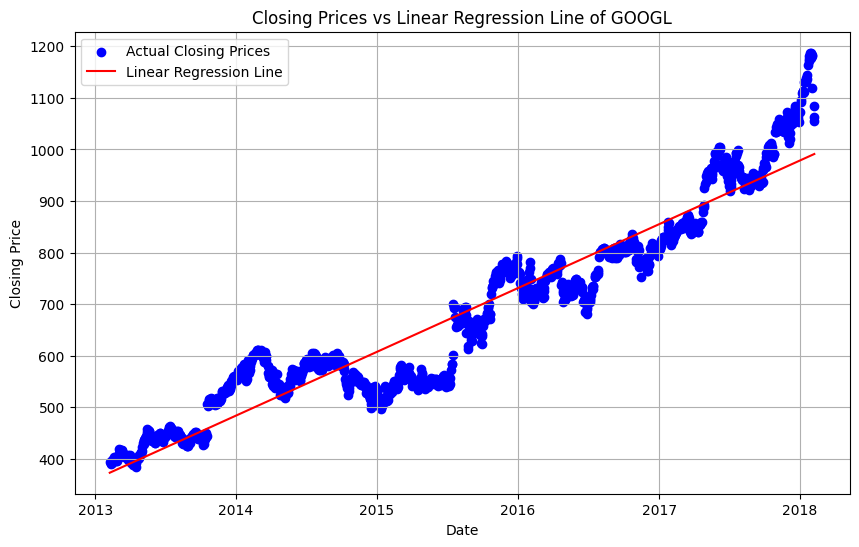

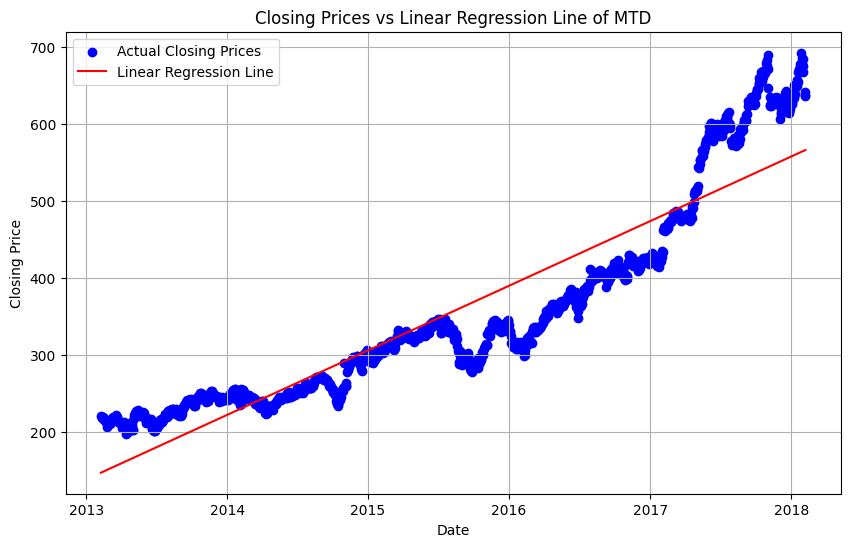

```python
model = LinearRegModel('PCLN')
model.plot()
model = LinearRegModel('AMZN')
model.plot()
model = LinearRegModel('GOOG')
model.plot()
model = LinearRegModel('GOOGL')
model.plot()
model = LinearRegModel('MTD')
model.plot()
```

And here are some of the worst stocks according to our model:

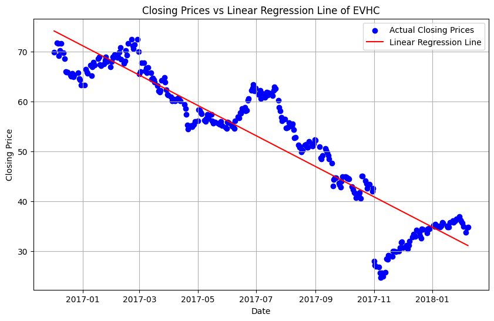

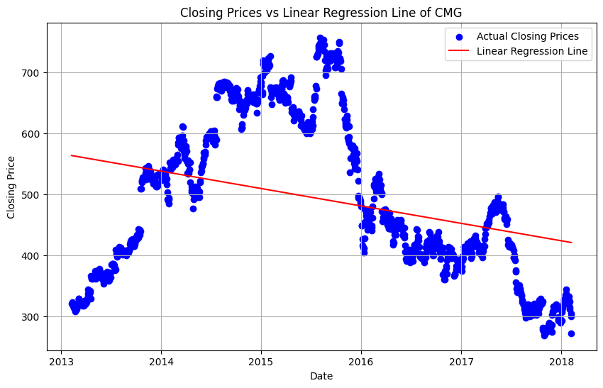

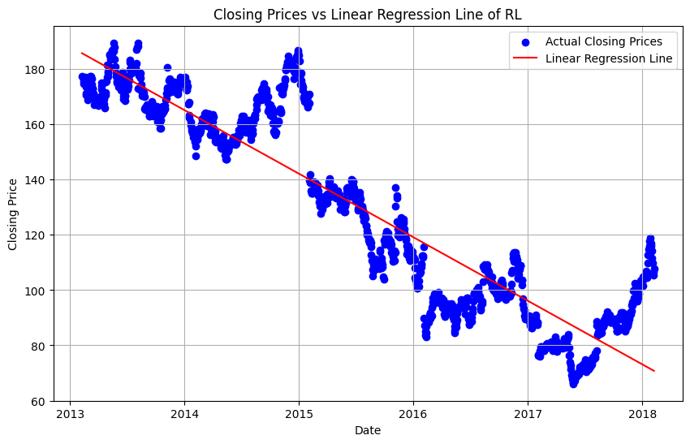

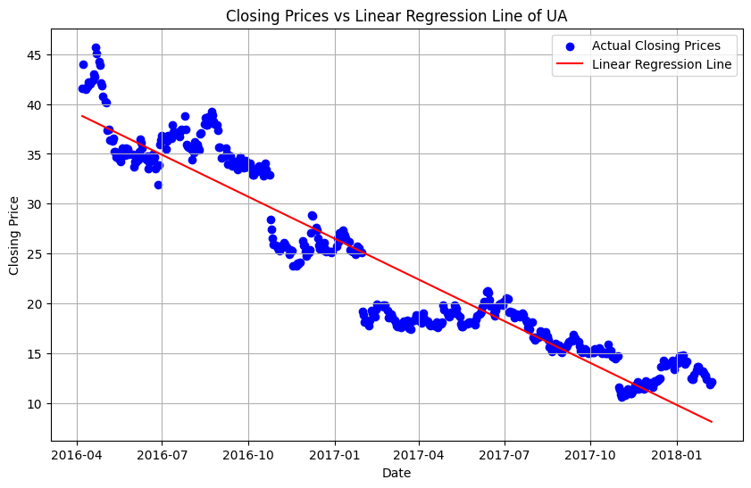

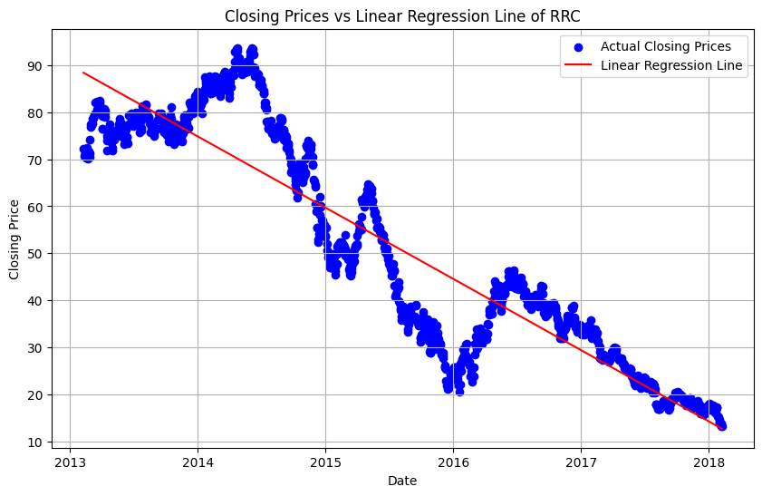

```python
model = LinearRegModel('EVHC')
model.plot()
model = LinearRegModel('CMG')
model.plot()
model = LinearRegModel('RL')
model.plot()
model = LinearRegModel('UA')
model.plot()
model = LinearRegModel('RRC')
model.plot()
```

As we can see our model did pretty well at classifying which stocks were and were not performing well which could provide useful information when making decisions about which stock you should buy and which stocks you should stay away from in order to maximize ROI.

## VISUALIZATION

In this section we will look at the residual error in our predictions from using linear regression by graphing the predicted values against the residual error (actual_value - predicted_value).

Here I've graphed out the differneces between the actual vs predicted values of the algorithm for our "top ranked" stocks. This is to show that the model has significant drawbacks in being able to actually predict day to day closing prices as they shift around dramatically. The model has suceeded in ranking some of the stocks that have historically grown / fallen in price but for any fine detail estimations it requires some significant improvement.

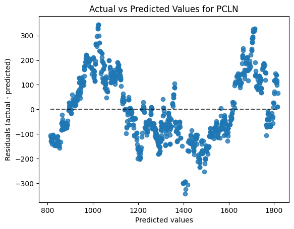

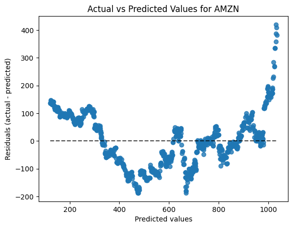

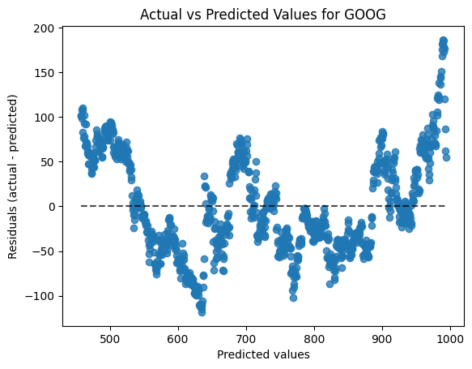

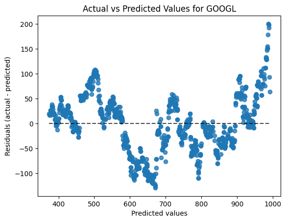

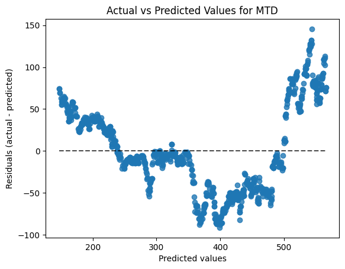

```python
model = LinearRegModel('PCLN')
model.showError()
model = LinearRegModel('AMZN')
model.showError()
model = LinearRegModel('GOOG')
model.showError()
model = LinearRegModel('GOOGL')
model.showError()
model = LinearRegModel('MTD')
model.showError()
```

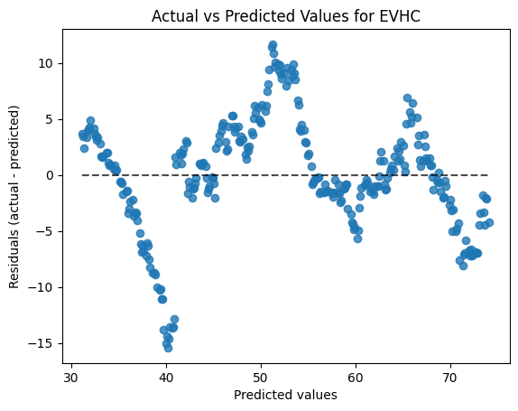

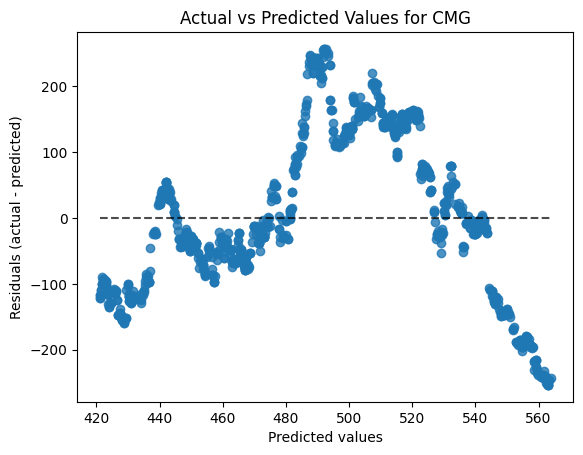

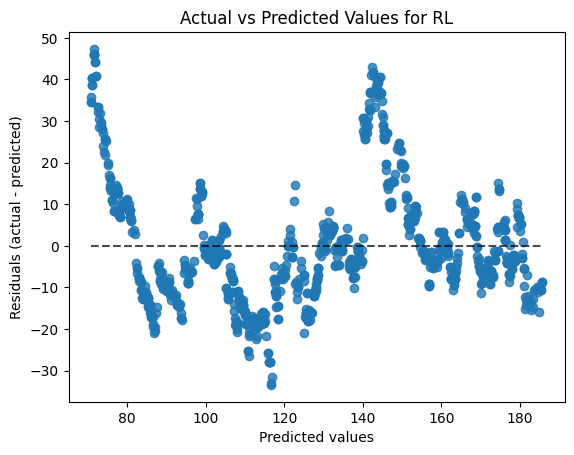

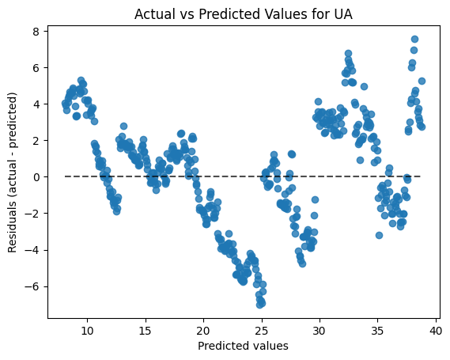

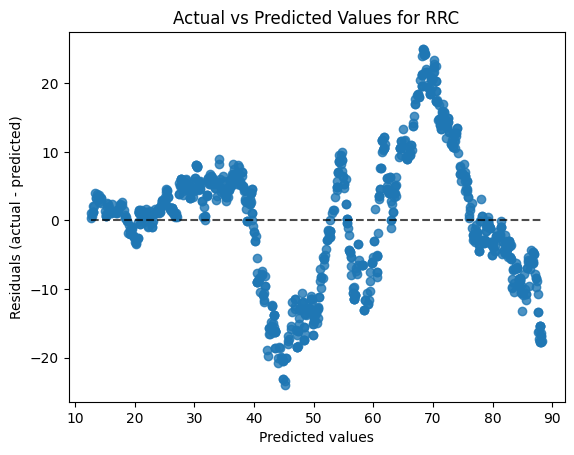

```python
model = LinearRegModel('EVHC')
model.showError()
model = LinearRegModel('CMG')
model.showError()
model = LinearRegModel('RL')
model.showError()
model = LinearRegModel('UA')
model.showError()
model = LinearRegModel('RRC')
model.showError()
```

## INSIGHTS AND CONCLUSION

The efficacy of the model in successfully predicting day to day stock prices leaves room for improvement, but it has managed to organize an average estimation of which stocks have historically performed the best over time. I think that for that ranking purpose the model has achieved its goal in being able to give its list of the best performing and worst performing overall stocks. This has given me insight into the potential pitfalls of linear regression in particular as well as machine learning overall. The question initially seems fairly straightforward in what we needed our model to be able to do to accomplish our goal, but when put into practice we found that it was a much more complex scenario, and there are many other models that might be better suited, but would require us to test and implement them individually, such as polynomial features or other regression/classifcation algorithms.

This project was intented to be a guide for both experienced and unexperienced traders who want to learn more about the stock behaviors in the S&P500. From this tutorial, they will be able to walk away with some machine learning skills in order to evaluate if a stock is a good investment and can use techniques such as linear regression to find the fastest growing stocks in the index. Although a trader should do more research on a stock than just its projected price and trend, this provides a good tool in complement to other technical and fundamental analysises for determining the soundness of a stock.